# ESM 204 HW 3

Sarah Hamilton, Carleigh Osen, and Maggie Hammond

5/2/2022

The following code contains an analysis of the distributional effects of a tax on electricity use on high and low income populations.

```r
co2_cost <- read_csv(here("HW3_data.csv")) %>%
  clean_names()
```

```r
#read in the data
co2_cost_income <- co2_cost %>%
  pivot_longer(cols = c(q_low_kwh, q_high_kwh),
               names_to = 'income',
               values_to = 'q_kwh') %>%
  mutate(income = case_when(
    income == "q_low_kwh" ~ "Low",
    income == "q_high_kwh" ~ "High"
  ))
```

# 1 Marginal Demand Linear Regression Model

```r
low_lm <- lm(price_cents ~ q_low_kwh,
             data = co2_cost)

# coefficients: intercept 23.3709671, Q coefficient -0.0001102

high_lm <- lm(price_cents ~ q_high_kwh,
              data = co2_cost)

# coefficients: intercept 31.61, Q coefficient -5.202e-05

extract_eq(model = low_lm, use_coefs = TRUE, coef_digits = 5)
```

$$\operatorname{\widehat{price\_cents}} = 23.37097 - 0.00011(\operatorname{q\_low\_kwh})$$

```r
extract_eq(model = high_lm, use_coefs = TRUE, coef_digits = 5)
```

$$\operatorname{\widehat{price\_cents}} = 31.60686 - 5e-05(\operatorname{q\_high\_kwh})$$

```r
low_mb <- function(x){23.37-.00011*x}
high_mb <- function(x){31.16 - 5.202e-05*x}


# to add the demands to find aggregate demand

low_lm_q <- lm(q_low_kwh ~ price_cents,
             data = co2_cost)


high_lm_q <- lm(q_high_kwh ~ price_cents,
             data = co2_cost)

extract_eq(model = low_lm_q, use_coefs = TRUE)
```

$$\operatorname{\widehat{q\_low\_kwh}} = 191672.48 - 7722.83(\operatorname{price\_cents})$$

```r
extract_eq(model = high_lm_q, use_coefs = TRUE)
```

$$\operatorname{\widehat{q\_high\_kwh}} = 584850.4 - 17716.67(\operatorname{price\_cents})$$

```r
# 191672.48 + 584850.4 + (-7722.83+17716.67 price)

# Qagg = 776522.88 - 25439.5P
# Pagg = 776522.88/25439.5 - Q/25439.5

# FOR DEMAND AGG P = 30.52 - 3.93e-5Q
```

# 2 Plot the Low and High Income Demand Curves

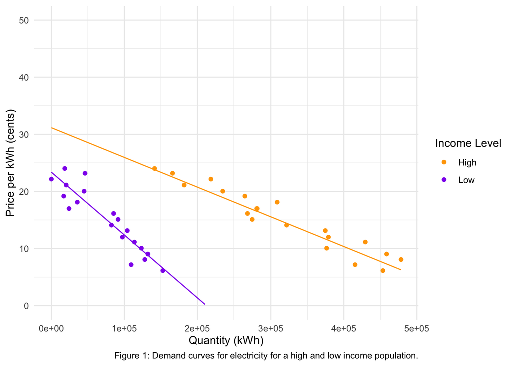

```r
#plot the functions
ggplot(data = co2_cost_income, aes(y = price_cents, x = q_kwh)) +
  geom_point(aes(color = income)) +
  scale_color_manual(values = c('orange', 'purple2')) +
  stat_function(fun = low_mb, color = "purple2") +
  stat_function(fun = high_mb, color = "orange") +
  ylim(0, 50) +
  labs(x = "Quantity (kWh)",
       y = "Price per kWh (cents)",
       color = "Income Level",
       caption = "Figure 1: Demand curves for electricity for a high and low income population.") +
  theme_minimal()
```

# 3 Calculate Aggregate Demand and Supply Curves and Plot Them

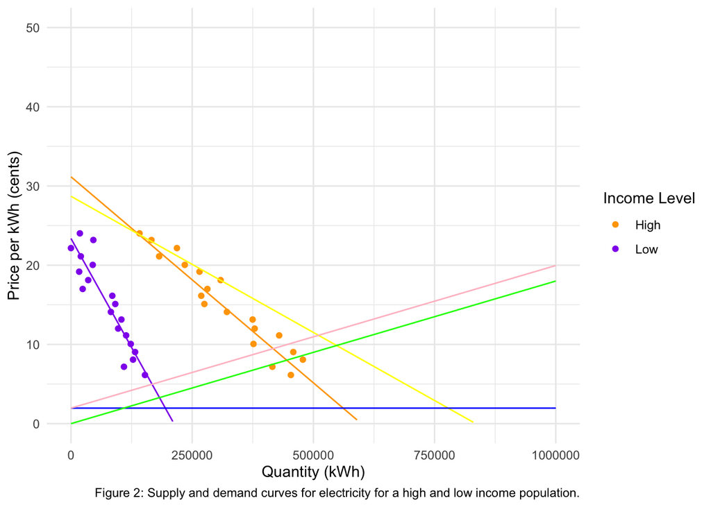

```r
#Question 2: Aggregate demand function
#Qagg = Ql+Qh = (23.37-Pl)/0.00011 + (31.16-Ph)/0.00005
#Rearranged: Pagg = 28.7-Qagg/29091
d_agg <- function(x){28.7-x/29091}

#MEC function
#Calculated by converting $51/ton to cents/kWh:
#5100 cents/ton * 1 ton/2204.6 lb * 0.85 lb CO2/1 kWh = 1.96 cents/kWh
mec <- function(x){1.96}

#MPC function
#Calculated using the point (0,0) and equilibrium, where P=10 cents (544745, 10).
#Qagg(10 cents) = 835655-29091*10 = 544745 kWh
mpc <- function(x){0.000018*x}

#MSC function (MPC+MEC)
#Calculated by adding MEC to MPC
msc <- function(x){0.000018*x+1.96}

#Plot all functions
ggplot(data = co2_cost_income, aes(y = price_cents, x = q_kwh)) +
  geom_point(aes(color = income)) +
  scale_color_manual(values = c('orange', 'purple2', 'yellow', 'blue', 'green', 'pink')) +
  stat_function(fun = low_mb, color = "purple2") +
  stat_function(fun = high_mb, color = "orange") +
  stat_function(fun = d_agg, color = 'yellow') +
  stat_function(fun = mec, color = 'blue') +
  stat_function(fun = mpc, color = 'green') +
  stat_function(fun = msc, color = 'pink') +
  ylim(0, 50) +
  xlim(0, 1000000) +
  labs(x = "Quantity (kWh)",
       y = "Price per kWh (cents)",
       color = "Income Level",
      caption = "Figure 2: Supply and demand curves for electricity for a high and low income population.") +
  theme_minimal()
```

# 4 Calculate CS, PS, and Environmental Costs

```r
#Functions to calculate CS, PS, and Environmental Costs

#Free Market equilibrium (units of cents and kWh)
p_free <- 10
q_free <- 544745

q_free_high <- 423200
q_free_low <-121545

#Socially optimal equilibrium
p_social <- 11.15
q_social <- 510550

q_social_high <- 400200
q_social_low <- 111091

#Agg Consumer Surplus using MSC
cs_msc <- function(p_social, q_social, q_social_high, q_social_low){

  cs_high <- 0.5*(high_mb(0)-p_social)*q_social_high
  cs_low <- 0.5*(low_mb(0)-p_social)*q_social_low
  cs_agg <- cs_low + cs_high

  return(cs_agg) #cs_high, cs_low,
}

#Agg Producer Surplus using MSC
ps_msc <- function(p_social, q_social){

  ps_agg <- 0.5*(p_social-msc(0))*q_social

  return(ps_agg)
}

#Agg Consumer Surplus using MPC
cs_mpc <- function(p_free, q_free, q_free_high, q_free_low){

  cs_high <- 0.5*(high_mb(0)-p_free)*q_free_high
  cs_low <- 0.5*(low_mb(0)-p_free)*q_free_low
  cs_agg <- cs_low + cs_high

  return(cs_agg) #cs_high, cs_low,
}

#Agg Producer Surplus using MPC
ps_mpc <- function(p_free, q_free){

  ps_agg <- 0.5*(p_free-mpc(0))*q_free

  return(ps_agg)
}

#Total Environmental Costs using MEC
env_costs <- function(q){
  ec <- q*mec(q)

  return(ec)
}

#Question 2 (cont.)
#Benefit to consumers and producers under status quo
consumer_benefit_sq <- cs_mpc(p_free, q_free, q_free_high, q_free_low)
producer_benefit_sq <- ps_mpc(p_free, q_free)

#Total environmental costs under status quo
total_environmental_cost <- env_costs(q_free)
```

Question 2 (cont.): Under status quo, consumer surplus is 5.2899843^{4} dollars and producer surplus is 2.723725^{4} dollars. The total environmental cost under status quo is 1.0677002^{4} dollars.

# 5 Calculate High and Low Income Consumer Benefits

```r
#Question 3
#Agg Consumer Surplus for HIGH income using MPC
cs_mpc_high <- function(p_free, q_free, q_free_high){

  cs_high <- 0.5*(high_mb(0)-p_free)*q_free_high

  return(cs_high)
}

#Agg Consumer Surplus for LOW income using MPC
cs_mpc_low <- function(p_free, q_free, q_free_low){

  cs_low <- 0.5*(low_mb(0)-p_free)*q_free_low

  return(cs_low)
}

consumer_benefit_sq_high <- cs_mpc_high(p_free, q_free, q_free_high)
consumer_benefit_sq_low <- cs_mpc_low(p_free, q_free, q_free_low)
```

Question 3 (cont.): The consumer benefit for high income consumers is 4.477456^{4} dollars while the consumer benefit for low income consumers is 8125.28325 dollars. High income consumers have a significantly higher benefit.

# 6 Derive the Optimal Tax

The optimal tax is equal to the marginal external cost at the socially optimal equilibrium. Because the marginal external cost is constant at the social cost of carbon, the optimal tax is equal to the social cost of carbon. Therefore the optimal tax for a SCC of $51 per metric ton of CO2 is *1.96 cents per kWh*.

```r
#Effect of tax on the amount of electricity produced and consumed (change in Q)
q_change <- q_free - q_social

#Effect of tax on the price of electricity (change in P)
p_change <- p_social - p_free

#Effect of tax on overall welfare of high income consumers
cs_msc_high <- function(p_social, q_social, q_social_high){

  cs_high <- 0.5*(high_mb(0)-p_social)*q_social_high

  return(cs_high)
}

consumer_benefit_social_high <- cs_msc_high(p_social, q_social, q_social_high)
high_income_change <- consumer_benefit_sq_high - consumer_benefit_social_high

#Effect of tax on overall welfare of low income consumers
cs_msc_low <- function(p_social, q_social, q_social_low){

  cs_low <- 0.5*(low_mb(0)-p_social)*q_social_low

  return(cs_low) #cs_high, cs_low,
}
consumer_benefit_social_low <- cs_msc_low(p_social, q_social, q_social_low) - env_costs(q_social)
#subtract environmental costs from social scenario because low income people bear the burden
low_income_change <- consumer_benefit_sq_low - env_costs(q_free) - consumer_benefit_social_low
#subtract environmental costs from status quo scenario too because low income people bear the burden

#Effect of tax on overall welfare of electricity producers
producer_change <- ps_mpc(p_free, q_free) - ps_msc(p_social, q_social)

#Effect of tax on total environmental damage
env_costs_change <- env_costs(q_free) - env_costs(q_social)

#Effect of tax on total tax revenue generated
tax_rev <- q_social*mec(q_social)
```

Question 4:

- Effect of tax on the amount of electricity produced and consumed: 3.4195^{4} kWh LESS are produced and consumed.
- Effect of tax on the price of electricity: Electricity is 1.15 cents more expensive per kWh.
- Effect of tax on overall welfare of high income consumers: High income consumers get 4734.55 dollars less of surplus.
- Effect of tax on overall welfare of low income consumers: Low income consumers get 667.40115 dollars less of surplus.
- Effect of tax on overall welfare of electricity producers: Producers get 3777.4775 dollars less of surplus.
- Effect of tax on total environmental damage: Environmental damage decreases by 670.222 dollars.
- Effect of tax on total tax revenue generated: Tax revenue will increase by 1.000678^{4} dollars.

# 7 Welfare Effects of Varying Social Cost of Carbon

```r
#MEC function
#Calculated by converting $75/ton to cents/kWh:
#7500 cents/ton * 1 ton/2204.6 lb * 0.85 lb CO2/1 kWh =  2.89 cents/kWh

#MEC function
#Calculated by converting $100/ton to cents/kWh:
#10000 cents/ton * 1 ton/2204.6 lb * 0.85 lb CO2/1 kWh =  3.86 cents/kWh

#MEC function
#Calculated by converting $125/ton to cents/kWh:
#12500 cents/ton * 1 ton/2204.6 lb * 0.85 lb CO2/1 kWh =  4.82 cents/kWh

#MEC function
#Calculated by converting $150/ton to cents/kWh:
#15000 cents/ton * 1 ton/2204.6 lb * 0.85 lb CO2/1 kWh = 5.78 cents/kWh

consumer_benefit_social_high <- cs_msc_high(p_social, q_social, q_social_high)

consumer_benefit_social_low <- cs_msc_low(p_social, q_social, q_social_low) - env_costs(q_social)

producer_surplus <- ps_msc(p_social, q_social)
```

- **high income total welfare is 4.004001^{4} dollars.
- **low income total welfare is -3219.1199 dollars.
- **producer surplus is 2.3459773^{4} dollars.

```r
q5 <- read_csv(here("q5excel.csv")) %>%
  clean_names()
#note to maggie: we probably dont wanna clean names here bc you formatted the excel names to be nice
```

# 8 Effect of Home Solar Generation for High Income Groups

```r
#work for part C
q5_clean <- q5 %>%
  clean_names() %>%
  mutate(env_damage = mec*social_q_agg)

env_damage_lm <- lm(env_damage ~ mec, data = q5_clean)
extract_eq(model = env_damage_lm, use_coefs = TRUE, coef_digits = 5)
```

$$\operatorname{\widehat{env\_damage}} = 336638.61654 + 382446.52933(\operatorname{mec})$$

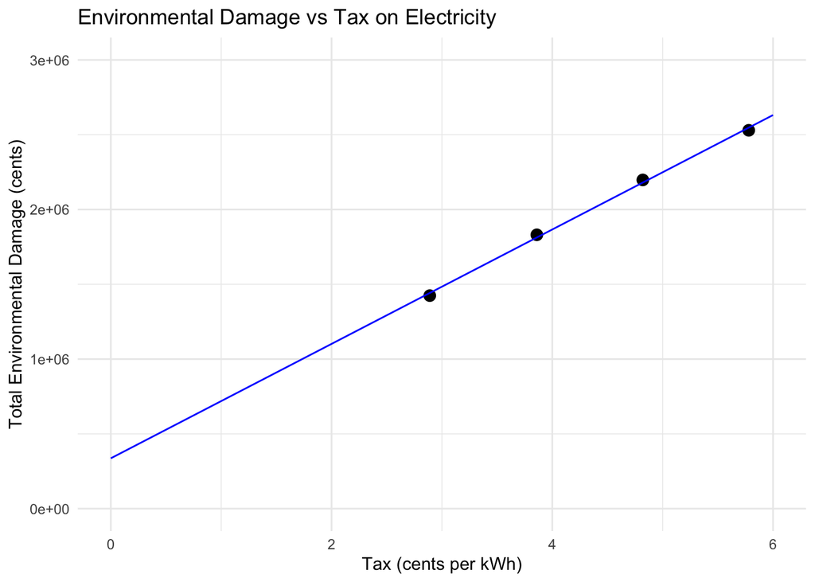

```r
env_damage_fun <- function(x){336638.6 + 382446.5 * x}

#equation for environmental damage as a function of mec or tax
#environmental damage = 336638.6 + 382446.5 * tax
#if we set environmental damage = 664643 cents:
tax_equal <- (664643 - 336638.6)/382446.5

ggplot(data = q5_clean, aes(x = mec, y = env_damage)) +
  geom_point(size = 3) +
  labs(x = "Tax (cents per kWh)",
       y = "Total Environmental Damage (cents)",
       title = "Environmental Damage vs Tax on Electricity") +
  theme_minimal() +
  stat_function(fun = env_damage_fun, color = "blue") +
  xlim(0, 6) +
  ylim(0, 3000000)
```

```r
#by plugging the environmental damage from #5 in, we get a tax of 0.86 cants per kWh
```